# Grays Harbor Recreational Crab Harvest Estimate

## 8. Monthly estimates

The season total broken out by month, with per-month credible intervals, showing the within-season harvest trajectory.

```r
# ---- 7.8 MONTHLY ESTIMATES ----
cat("\n", strrep("=",60), "\n MONTHLY ESTIMATES\n", strrep("=",60), "\n")

days_full <- prep_days_crab(params$est_date_start, params$est_date_end,
                            params, L_eff_model = L_eff_model)

month_lookup <- days_full |>
  mutate(month_label = format(event_date, "%Y-%m")) |>
  select(event_date, month_label)

all_months <- sort(unique(month_lookup$month_label))
monthly_C_draws <- matrix(0, nrow = n_draws_max, ncol = length(all_months),
                          dimnames = list(NULL, all_months))
monthly_E_draws <- matrix(0, nrow = n_draws_max, ncol = length(all_months),
                          dimnames = list(NULL, all_months))

for(cg in bss_catch_groups) {
  for(pop in c("shore","private_boat")) {
    for(ss in list(subseason_1, subseason_2)) {
      label <- paste0(pop, "_", ss$name, "_", cg)
      pe_label <- paste0(pop, "_", ss$name)
      b <- bss_all[[label]]

      days_ss <- prep_days_crab(ss$start, ss$end, params, L_eff_model = L_eff_model)
      days_ss$month_label <- format(days_ss$event_date, "%Y-%m")

      if(bss_use_pe_for(b)) {   # B1.8: PE if insufficient data OR failed scale-aware gate
        summ_ss <- prep_population_summary(dwg, pop, ss$start, ss$end, params)
        # Fix 2 (v7.0), POOL-3 (v7.6): population-aware daily effort so the monthly
        # PE SHARE uses the same effort definition run_pe_pooled() uses. run_pe_pooled() builds the
        # private-boat effort series on the gear-DEPLOYMENT scale,
        # mean_count * gear_per_group * tau_boat (day-length-free), and shore as
        # crabber-hours, mean_count * crabbers_per_gear * day_length. The share is
        # normalized, so component and port TOTALS are unaffected; only the across-
        # month distribution changes. gear_per_group is recomputed here from the same
        # sub-season interview filter run_pe_pooled() uses so the two stay consistent.
        is_boat_pe <- str_detect(pop, "private_boat")
        gpg_pe <- params$gear_per_group_default %||% 4.0
        tau_pe <- params$tau_boat_prior_mu %||% 1.2
        if(is_boat_pe) {
          rd_pe <- summ_ss$interview |>
            filter(!is.na(number_of_gear), number_of_gear > 0, angler_count > 0)
          if(nrow(rd_pe) > 0) gpg_pe <- mean(rd_pe$number_of_gear)
        }
        pe_daily <- summ_ss$effort_index |>
          filter(count_sequence <= params$bss_max_count_seq) |>
          group_by(event_date) |>
          summarise(mean_count = mean(count_quantity), .groups = "drop") |>
          left_join(days_ss |> select(event_date, day_length, month_label), by = "event_date") |>
          mutate(daily_effort = if(is_boat_pe) mean_count * gpg_pe * tau_pe
                                else mean_count * summ_ss$crabbers_per_gear * day_length)

        monthly_pe <- pe_daily |>
          group_by(month_label) |>
          summarise(month_effort = sum(daily_effort), .groups = "drop") |>
          mutate(share = month_effort / sum(month_effort))

        pe_catch_total <- pe_all[[pe_label]][[cg]] %||% 0
        pe_effort_total <- pe_all[[pe_label]]$effort_total

        for(m in monthly_pe$month_label) {
          if(m %in% all_months) {
            sh <- monthly_pe$share[monthly_pe$month_label == m]
            monthly_C_draws[, m] <- monthly_C_draws[, m] + pe_catch_total * sh
            monthly_E_draws[, m] <- monthly_E_draws[, m] + pe_effort_total * sh
          }
        }
      } else {
        # Use C_expected (no Poisson noise) for monthly totals
        C_exp_bss <- rstan::extract(b$fit, "C_expected")$C_expected
        E_bss <- rstan::extract(b$fit, "E")$E
        n_fit_draws <- dim(C_exp_bss)[1]

        C_daily_mat <- C_exp_bss[,1,,1]
        E_daily_mat <- E_bss[,1,,1]

        for(m in unique(days_ss$month_label)) {
          day_idx <- which(days_ss$month_label == m)
          if(length(day_idx) == 0) next
          month_C <- if(length(day_idx)==1) C_daily_mat[, day_idx] else rowSums(C_daily_mat[, day_idx])
          month_E <- if(length(day_idx)==1) E_daily_mat[, day_idx] else rowSums(E_daily_mat[, day_idx])
          idx <- rep_len(1:n_fit_draws, n_draws_max)
          if(m %in% all_months) {
            monthly_C_draws[, m] <- monthly_C_draws[, m] + month_C[idx]
            monthly_E_draws[, m] <- monthly_E_draws[, m] + month_E[idx]
          }
        }
      }
    }
  }
}

# Add commercial/charter
if(!is.null(pe_all$comm_charter$daily_est)) {
  comm_daily <- pe_all$comm_charter$daily_est |>
    mutate(month_label = format(date, "%Y-%m"))
  comm_total <- pe_all$comm_charter$Dungeness_Kept
  total_sampled_dung <- sum(comm_daily$est_dung)
  if(total_sampled_dung > 0) {
    for(m in unique(comm_daily$month_label)) {
      if(m %in% all_months) {
        share <- sum(comm_daily$est_dung[comm_daily$month_label == m]) / total_sampled_dung
        monthly_C_draws[, m] <- monthly_C_draws[, m] + comm_total * share
      }
    }
  }
}

monthly_summary <- tibble(
  Month = all_months,
  BSS_Catch_median = apply(monthly_C_draws, 2, median),
  BSS_Catch_lo95   = apply(monthly_C_draws, 2, quantile, 0.025),
  BSS_Catch_hi95   = apply(monthly_C_draws, 2, quantile, 0.975),
  BSS_Effort_median = apply(monthly_E_draws, 2, median),
  BSS_Effort_lo95   = apply(monthly_E_draws, 2, quantile, 0.025),
  BSS_Effort_hi95   = apply(monthly_E_draws, 2, quantile, 0.975)
) |>
  mutate(across(where(is.numeric), round))

print(monthly_summary |> select(Month, BSS_Catch_median, BSS_Catch_lo95, BSS_Catch_hi95))
write.csv(monthly_summary, file.path(output_dir, "monthly_estimates.csv"), row.names = FALSE)

p_monthly <- monthly_summary |>
  mutate(Month = factor(Month, levels = all_months)) |>
  ggplot(aes(x = Month)) +
  geom_col(aes(y = BSS_Catch_median), fill = "steelblue", alpha = 0.7) +
  geom_errorbar(aes(ymin = BSS_Catch_lo95, ymax = BSS_Catch_hi95), width = 0.3) +
  labs(title = "Monthly Dungeness Catch (Expected, no Poisson noise)",
       x = "Month", y = "Dungeness crab caught") +
  theme_bw() + theme(axis.text.x = element_text(angle = 45, hjust = 1))
ggsave(file.path(output_dir, "plot_monthly_catch.png"), p_monthly, width = 12, height = 6)


# ===========================================================================
```

```r
report_table(monthly_summary, 'Monthly harvest estimates with 95% intervals.'); if (exists('p_monthly')) print(p_monthly)
```

Monthly harvest estimates with 95% intervals.

| Month | BSS_Catch_median | BSS_Catch_lo95 | BSS_Catch_hi95 | BSS_Effort_median | BSS_Effort_lo95 | BSS_Effort_hi95 |
| --- | --- | --- | --- | --- | --- | --- |
| 2024-09 | 1,615 | 1,296 | 2,123 | 1,182 | 955 | 1,538 |
| 2024-10 | 3,195 | 2,651 | 3,976 | 2,323 | 1,944 | 2,871 |
| 2024-11 | 2,725 | 2,136 | 3,538 | 2,069 | 1,636 | 2,661 |
| 2024-12 | 9,757 | 8,953 | 10,897 | 2,280 | 1,872 | 2,847 |
| 2025-01 | 7,320 | 6,780 | 8,108 | 2,482 | 1,996 | 3,209 |
| 2025-02 | 1,680 | 1,368 | 2,174 | 1,533 | 1,186 | 2,075 |
| 2025-03 | 1,865 | 1,317 | 2,845 | 2,060 | 1,641 | 2,724 |
| 2025-04 | 3,526 | 2,480 | 5,258 | 3,390 | 2,661 | 4,461 |
| 2025-05 | 8,150 | 5,366 | 13,400 | 3,960 | 3,145 | 5,232 |
| 2025-06 | 4,410 | 2,773 | 7,494 | 3,314 | 2,410 | 4,832 |
| 2025-07 | 12,707 | 7,312 | 23,882 | 7,406 | 5,580 | 10,433 |
| 2025-08 | 19,280 | 12,437 | 31,660 | 8,345 | 6,542 | 11,010 |
| 2025-09 | 5,873 | 3,420 | 10,982 | 3,612 | 2,721 | 5,033 |

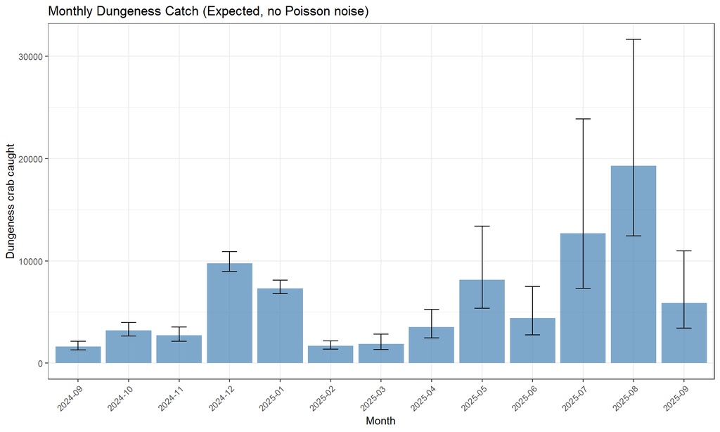

Monthly Dungeness catch with 95% intervals.

### 8.1 Monthly catch by crabbing mode

The monthly trajectory split by mode (shore, private boat, commercial/charter). The uncertainty source matches the method selected for each component, so the boat interval here is a lower bound when the boat is on PE.

```r
# 7.8b MONTHLY ESTIMATES BY CRABBING MODE (with per-mode uncertainty)
# ===========================================================================
# Companion to plot_monthly_catch.png. Breaks the monthly Dungeness catch out by
# crabbing mode, each month with a 95% interval. The uncertainty source matches
# the method actually selected for each component (convergence_report / pe_vs_bss):
#   Shore  (BSS, both sub-seasons): full posterior. Monthly catch draws are summed
#          from the daily C_expected draws, then 2.5/50/97.5 quantiles.
#   Private Boat: method is per sub-season (v7.0 scale-aware gate, B1.8). On the
#          2024-25 data the all-gear sub-season passes the gate and uses the BSS
#          posterior (full daily C_expected draws, CV ~27%), while the ring-net
#          sub-season has too few interviews (< bss_min_interviews) and uses PE.
#          The PE branch distributes the selected PE point across months by monthly
#          effort share, then applies a design-based relative SE (stratified effort
#          SE / effort total) as ONE per-component lognormal scale shared across
#          months, so the monthly catches move together and the boat total carries
#          that relative SE. NOTE: the PE branch captures effort sampling
#          uncertainty but NOT CPUE sampling uncertainty, so a PE sub-season's
#          interval is a lower bound; the BSS posterior is the fuller
#          characterization. Branch selection is driven by bss_use_pe_for(), so if a
#          component's gate verdict changes in a future run this block follows it
#          automatically.
#   Commercial/Charter (census): point distributed by sampled-harvest share with
#          a catch-per-vessel sampling CV as the relative SE (small, high coverage).
# Fix 2 (v7.0): the PE monthly effort share is now population-aware (see the PE
# branch below). The boat uses the flat 24 h gear-hours run_pe_pooled() uses; shore keeps
# crabber-hours * day_length. This removes the prior day_length over-weighting of
# long-day summer months in the boat monthly distribution (totals were, and remain,
# unaffected; only the across-month split changed). The same formula lives in 7.8;
# the two PE-share blocks are still duplicated (with a minor na.rm difference) and
# are a candidate for consolidation into one helper in a future pass.
cat("\n", strrep("=",60), "\n MONTHLY ESTIMATES BY MODE\n", strrep("=",60), "\n")

modes_lvl <- c("Shore", "Private Boat", "Commercial/Charter")
mk_mat <- function() matrix(0, nrow = n_draws_max, ncol = length(all_months),
                            dimnames = list(NULL, all_months))
bymode_C <- setNames(lapply(modes_lvl, function(x) mk_mat()), modes_lvl)

# lognormal scale, mean 1, target relative SE (mean-preserving)
rln_scale <- function(n, rel_se) {
  rel_se <- max(rel_se, 1e-4)
  sdlog  <- sqrt(log(1 + rel_se^2))
  exp(stats::rnorm(n, -sdlog^2 / 2, sdlog))
}

for(cg in bss_catch_groups) {
  for(pop in c("shore","private_boat")) {
    mode_nm <- if(pop == "shore") "Shore" else "Private Boat"
    for(ss in list(subseason_1, subseason_2)) {
      label    <- paste0(pop, "_", ss$name, "_", cg)
      pe_label <- paste0(pop, "_", ss$name)
      b <- bss_all[[label]]

      days_ss <- prep_days_crab(ss$start, ss$end, params, L_eff_model = L_eff_model)
      days_ss$month_label <- format(days_ss$event_date, "%Y-%m")

      if(bss_use_pe_for(b)) {   # B1.8: PE if insufficient data OR failed scale-aware gate
        summ_ss <- prep_population_summary(dwg, pop, ss$start, ss$end, params)
        # Fix 2 (v7.0), POOL-3 (v7.6): population-aware daily effort, identical
        # rationale to 7.8. Boat uses the gear-DEPLOYMENT scale
        # (mean_count * gear_per_group * tau_boat); shore keeps crabber-hours
        # (mean_count * crabbers_per_gear * day_length). Share is normalized so
        # totals are unaffected; only the monthly split changes.
        is_boat_pe <- str_detect(pop, "private_boat")
        gpg_pe <- params$gear_per_group_default %||% 4.0
        tau_pe <- params$tau_boat_prior_mu %||% 1.2
        if(is_boat_pe) {
          rd_pe <- summ_ss$interview |>
            filter(!is.na(number_of_gear), number_of_gear > 0, angler_count > 0)
          if(nrow(rd_pe) > 0) gpg_pe <- mean(rd_pe$number_of_gear)
        }
        pe_daily <- summ_ss$effort_index |>
          filter(count_sequence <= params$bss_max_count_seq) |>
          group_by(event_date) |>
          summarise(mean_count = mean(count_quantity), .groups = "drop") |>
          left_join(days_ss |> select(event_date, day_length, month_label), by = "event_date") |>
          mutate(daily_effort = if(is_boat_pe) mean_count * gpg_pe * tau_pe
                                else mean_count * summ_ss$crabbers_per_gear * day_length)
        monthly_pe <- pe_daily |>
          group_by(month_label) |>
          summarise(month_effort = sum(daily_effort, na.rm = TRUE), .groups = "drop") |>
          mutate(share = month_effort / sum(month_effort))

        pe_catch_total <- pe_all[[pe_label]][[cg]] %||% 0
        eff_total <- pe_all[[pe_label]]$effort_total %||% NA_real_
        eff_se    <- pe_all[[pe_label]]$effort_se %||% NA_real_
        rel_se <- if(!is.na(eff_total) && eff_total > 0 && !is.na(eff_se) && eff_se > 0)
                    eff_se / eff_total else 0.30
        scale_draws <- rln_scale(n_draws_max, rel_se)   # common effort-level uncertainty

        for(m in monthly_pe$month_label) {
          if(m %in% all_months) {
            sh <- monthly_pe$share[monthly_pe$month_label == m]
            bymode_C[[mode_nm]][, m] <- bymode_C[[mode_nm]][, m] + (pe_catch_total * sh) * scale_draws
          }
        }
      } else {
        C_exp_bss   <- rstan::extract(b$fit, "C_expected")$C_expected
        n_fit_draws <- dim(C_exp_bss)[1]
        C_daily_mat <- C_exp_bss[,1,,1]
        for(m in unique(days_ss$month_label)) {
          day_idx <- which(days_ss$month_label == m)
          if(length(day_idx) == 0 || !(m %in% all_months)) next
          month_C <- if(length(day_idx)==1) C_daily_mat[, day_idx] else rowSums(C_daily_mat[, day_idx])
          idx <- rep_len(1:n_fit_draws, n_draws_max)
          bymode_C[[mode_nm]][, m] <- bymode_C[[mode_nm]][, m] + month_C[idx]
        }
      }
    }
  }
}

# Commercial/charter (census): distribute by sampled-harvest share, with a
# catch-per-vessel sampling CV as the relative SE (robust fallback if unavailable).
if(!is.null(pe_all$comm_charter$daily_est)) {
  comm_daily    <- pe_all$comm_charter$daily_est |> mutate(month_label = format(date, "%Y-%m"))
  comm_total    <- pe_all$comm_charter$Dungeness_Kept %||% 0
  total_sampled <- sum(comm_daily$est_dung)
  rel_se_comm <- tryCatch({
    cpv <- dwg$interview |> filter(population == "comm_charter") |> pull(dungeness_kept)
    cpv <- cpv[is.finite(cpv)]
    if(length(cpv) > 1 && mean(cpv) > 0) (sd(cpv) / sqrt(length(cpv))) / mean(cpv) else 0.12
  }, error = function(e) 0.12)
  scale_comm <- rln_scale(n_draws_max, rel_se_comm)
  if(total_sampled > 0) {
    for(m in unique(comm_daily$month_label)) {
      if(m %in% all_months) {
        sh <- sum(comm_daily$est_dung[comm_daily$month_label == m]) / total_sampled
        bymode_C[["Commercial/Charter"]][, m] <- bymode_C[["Commercial/Charter"]][, m] + (comm_total * sh) * scale_comm
      }
    }
  }
}

monthly_bymode <- purrr::map_dfr(modes_lvl, function(md) {
  M <- bymode_C[[md]]
  tibble(
    Mode   = md,
    Month  = all_months,
    median = apply(M, 2, median),
    lo95   = apply(M, 2, quantile, probs = 0.025),
    hi95   = apply(M, 2, quantile, probs = 0.975)
  )
}) |>
  mutate(Mode  = factor(Mode, levels = modes_lvl),
         Month = factor(Month, levels = all_months),
         across(c(median, lo95, hi95), round))

print(monthly_bymode, n = nrow(monthly_bymode))
write.csv(monthly_bymode, file.path(output_dir, "monthly_estimates_by_mode.csv"), row.names = FALSE)

mode_cols <- c("Shore" = "#2c7fb8", "Private Boat" = "#d95f0e", "Commercial/Charter" = "#31a354")

# (1) Grouped (dodged) bars, one colour per mode, with 95% interval error bars.
p_bymode_dodge <- monthly_bymode |>
  ggplot(aes(x = Month, y = median, fill = Mode)) +
  geom_col(position = position_dodge(width = 0.8), width = 0.75, alpha = 0.85) +
  geom_errorbar(aes(ymin = lo95, ymax = hi95),
                position = position_dodge(width = 0.8), width = 0.3) +
  scale_fill_manual(values = mode_cols) +
  labs(title = "Monthly Dungeness Catch by Crabbing Mode",
       subtitle = "Median with 95% interval. Shore: BSS posterior. Private Boat: BSS posterior (all-gear), PE point with design-based effort SE (ring-net). Commercial/Charter: census, catch-per-vessel CV.",
       x = "Month", y = "Dungeness crab caught", fill = "Mode") +
  theme_bw() +
  theme(axis.text.x = element_text(angle = 45, hjust = 1), legend.position = "top")
ggsave(file.path(output_dir, "plot_monthly_catch_by_mode.png"), p_bymode_dodge, width = 13, height = 6)

# (2) Faceted companion (free y) so shore and commercial panels stay readable
# next to the larger boat panel.
p_bymode_facet <- monthly_bymode |>
  ggplot(aes(x = Month, y = median, fill = Mode)) +
  geom_col(width = 0.7, alpha = 0.85) +
  geom_errorbar(aes(ymin = lo95, ymax = hi95), width = 0.3) +
  scale_fill_manual(values = mode_cols) +
  facet_wrap(~Mode, ncol = 1, scales = "free_y") +
  labs(title = "Monthly Dungeness Catch by Crabbing Mode",
       subtitle = "Median with 95% interval (free y-axis per panel)",
       x = "Month", y = "Dungeness crab caught") +
  theme_bw() +
  theme(axis.text.x = element_text(angle = 45, hjust = 1), legend.position = "none")
ggsave(file.path(output_dir, "plot_monthly_catch_by_mode_facet.png"), p_bymode_facet, width = 12, height = 9)


# ===========================================================================
```

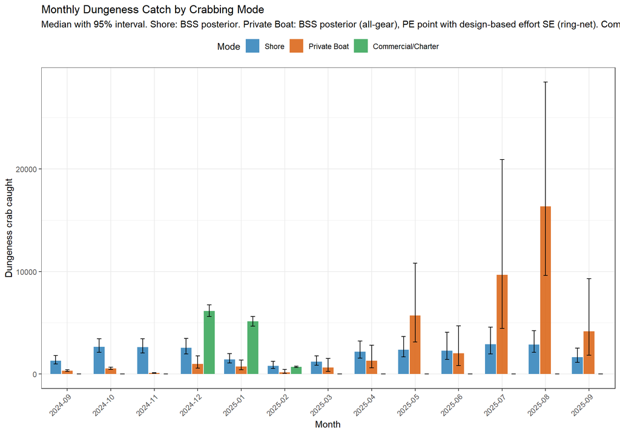

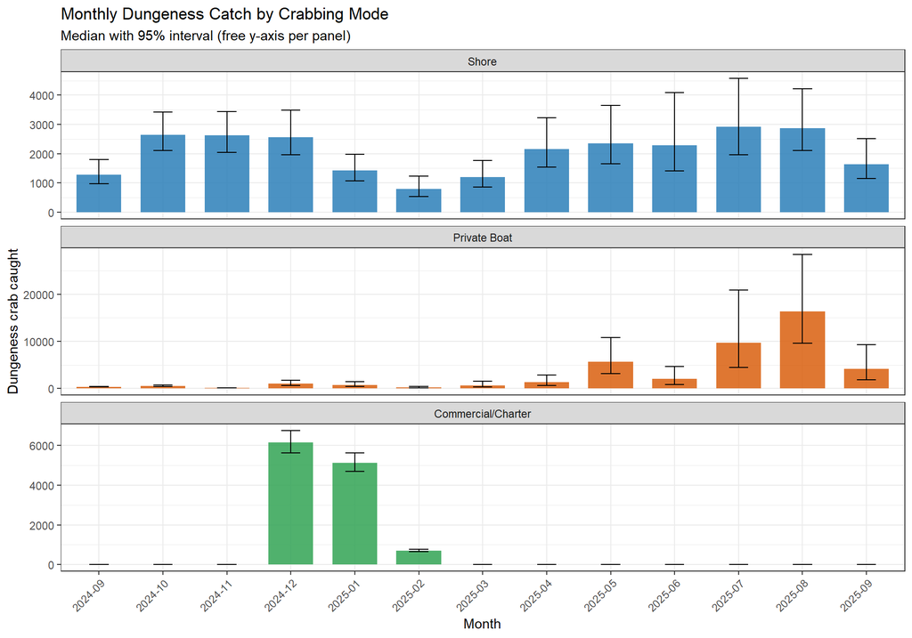

```r
for (nm in c('p_bymode_dodge','p_bymode_facet')) if (exists(nm)) print(get(nm))
```

## 9. Catch by crabbing mode

Total season catch attributed to each crabbing mode.

```r
# 7.9 CATCH BY CRABBING MODE
# ===========================================================================

cat("\n", strrep("=",60), "\n CATCH BY CRABBING MODE\n", strrep("=",60), "\n")

mode_table <- tibble(
  Mode = c("Shore (Dock/Jetty/Beach)", "Private Boat", "Commercial/Charter", "PORT TOTAL"),
  PE_Catch = c(
    (pe_all$shore_ring_net_only$Dungeness_Kept %||% 0) + (pe_all$shore_all_gear$Dungeness_Kept %||% 0),
    (pe_all$private_boat_ring_net_only$Dungeness_Kept %||% 0) + (pe_all$private_boat_all_gear$Dungeness_Kept %||% 0),
    pe_all$comm_charter$Dungeness_Kept %||% 0, NA
  ),
  PE_Effort = c(
    (pe_all$shore_ring_net_only$effort_total %||% 0) + (pe_all$shore_all_gear$effort_total %||% 0),
    (pe_all$private_boat_ring_net_only$effort_total %||% 0) + (pe_all$private_boat_all_gear$effort_total %||% 0),
    pe_all$comm_charter$effort_total %||% 0, NA
  )
)
mode_table$PE_Catch[4] <- sum(mode_table$PE_Catch[1:3], na.rm = TRUE)
mode_table$PE_Effort[4] <- sum(mode_table$PE_Effort[1:3], na.rm = TRUE)
print(mode_table |> mutate(across(where(is.numeric), round)))
write.csv(mode_table, file.path(output_dir, "catch_by_mode.csv"), row.names = FALSE)


# ===========================================================================
```

```r
report_table(mode_table, 'Season catch by crabbing mode.')
```

Season catch by crabbing mode.

| Mode | PE_Catch | PE_Effort |
| --- | --- | --- |
| Shore (Dock/Jetty/Beach) | 21,616.47 | 22,589.79 |
| Private Boat | 23,041.56 | 12,469.75 |
| Commercial/Charter | 12,007.12 | 282.81 |
| PORT TOTAL | 56,665.15 | 35,342.35 |

### 9.1 Catch by gear type

In the pooled model, gear-type catch is derived after estimation by applying interview-based gear proportions to the total (the gear-resolved model estimates it directly with uncertainty). Read these as proportional allocations, not independently modeled quantities.

```r
# 7.10 CATCH BY GEAR TYPE (proportional allocation from interviews)
#
# Pooled model: uses interview data to estimate the proportion of catch
# by primary gear type, then applies to combined catch estimates.
# ===========================================================================

cat("\n", strrep("=",60), "\n CATCH BY GEAR TYPE (proportional)\n", strrep("=",60), "\n")

gear_catch <- dwg$interview |>
  filter(population %in% c("shore","private_boat"), dungeness_kept > 0) |>
  mutate(
    gear_primary = case_when(
      str_detect(gear_type, "(?i)^pot|, pot|pot,") & !str_detect(gear_type, "(?i)slip ring") ~ "Pot",
      str_detect(gear_type, "(?i)ring net")     ~ "Ring Net",
      str_detect(gear_type, "(?i)trap|star")    ~ "Trap",
      str_detect(gear_type, "(?i)snare")        ~ "Snare",
      TRUE                                      ~ "Other"
    )
  )

gear_props <- gear_catch |>
  group_by(population, gear_primary) |>
  summarise(total_catch = sum(dungeness_kept), n_int = n(), .groups = "drop") |>
  group_by(population) |>
  mutate(prop_catch = total_catch / sum(total_catch)) |>
  ungroup()

cat("\n  Observed catch proportions by gear type:\n")
print(gear_props |> select(population, gear_primary, n_int, total_catch, prop_catch) |>
        mutate(prop_catch = round(prop_catch, 3)))

total_shore_catch <- pe_summary$Dungeness[1] + pe_summary$Dungeness[2]
total_boat_catch <- pe_summary$Dungeness[3] + pe_summary$Dungeness[4]

gear_estimates <- gear_props |>
  mutate(
    pop_total_PE = case_when(
      population == "shore" ~ total_shore_catch,
      population == "private_boat" ~ total_boat_catch),
    est_catch_PE = round(pop_total_PE * prop_catch)
  ) |>
  select(population, gear_primary, prop_catch, est_catch_PE) |>
  arrange(population, desc(prop_catch))

gear_estimates <- bind_rows(
  gear_estimates,
  tibble(population = "comm_charter", gear_primary = "Pot",
         prop_catch = 1.0, est_catch_PE = round(pe_all$comm_charter$Dungeness_Kept %||% 0))
)

gear_summary <- gear_estimates |>
  group_by(gear_primary) |>
  summarise(PE_Catch = sum(est_catch_PE), .groups = "drop") |>
  arrange(desc(PE_Catch)) |>
  mutate(Proportion = round(PE_Catch / sum(PE_Catch), 3))

cat("\n--- Catch by Gear Type (proportional allocation) ---\n")
print(gear_summary)
write.csv(gear_summary, file.path(output_dir, "catch_by_gear_type.csv"), row.names = FALSE)

p_gear <- gear_summary |>
  mutate(gear_primary = fct_reorder(gear_primary, PE_Catch)) |>
  ggplot(aes(x = gear_primary, y = PE_Catch, fill = gear_primary)) +
  geom_col() +
  geom_text(aes(label = sprintf("%s (%.0f%%)", format(PE_Catch, big.mark=","), Proportion*100)),
            hjust = -0.1, size = 3) +
  labs(title = "Estimated Dungeness Catch by Gear Type (Proportional Allocation)",
       x = "Gear Type", y = "Estimated Catch") +
  theme_bw() + theme(legend.position = "none") + coord_flip()
ggsave(file.path(output_dir, "plot_catch_by_gear_type.png"), p_gear, width = 10, height = 6)
```

```r
report_table(gear_summary, 'Season catch allocated by gear type (interview-proportion based).'); if (exists('p_gear')) print(p_gear)
```

Season catch allocated by gear type (interview-proportion based).

| gear_primary | PE_Catch | Proportion |
| --- | --- | --- |
| Pot | 38,506 | 0.68 |
| Trap | 9,140 | 0.16 |
| Ring Net | 7,253 | 0.13 |
| Snare | 1,543 | 0.03 |
| Other | 222 | 0.00 |

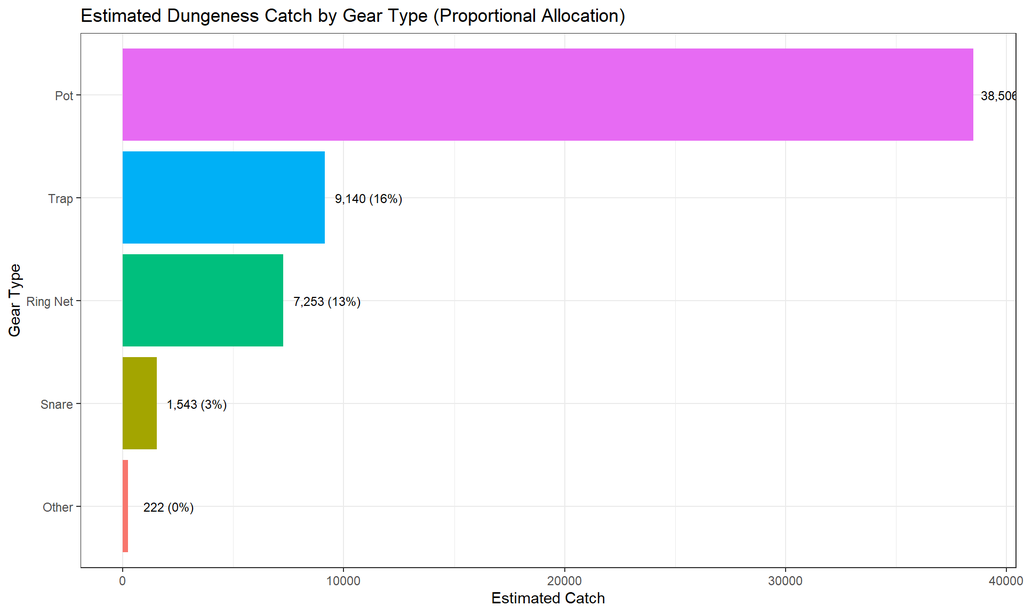

Catch by gear type.

## 10. Convergence report

The per-fit diagnostic table behind the gate decision: R-hat and effective sample size for the summed effort and catch, the divergent fraction, and the pass/fail flag. **Healthy:** `pass_convergence` TRUE with R-hat near 1.00 and effective sample size well above 400 on every fit that had sufficient data.

```r
# ---- 7.11 CONVERGENCE REPORT ----
# v7.0 (B1.8): the pass/fail decision and every diagnostic column are computed once
# in 7.6b (bss_compute_gate) and stored as bss_all[[label]]$gate_info, so this section
# is now pure assembly. This guarantees the report agrees with the method actually
# used in the totals (7.7/7.8/7.8b consume the same use_bss flag). All gate
# warnings were already emitted in 7.6b at fit time. Columns now include the
# scale-aware impact (impact_C_sd, impact_E_sd; the gating criterion) and retain
# the legacy level-distortion (distortion_C, distortion_E) as reported-only.
cat("\n", strrep("=",60), "\n CONVERGENCE REPORT\n", strrep("=",60), "\n")

convergence_df <- bind_rows(lapply(names(bss_all), function(label) bss_all[[label]]$gate_info))
print(convergence_df)
write.csv(convergence_df, file.path(output_dir, "convergence_report.csv"), row.names = FALSE)
```

```r
report_table(convergence_df, 'Per-fit convergence report (the basis for the PE-vs-BSS gate decision).', digits=4)
```

Per-fit convergence report (the basis for the PE-vs-BSS gate decision).

| fit | ar_resolution | divergences | divergence_fraction | treedepth_pct | C_sum_rhat | E_sum_rhat | C_sum_neff | E_sum_neff | B1_C_rhat | impact_C_sd | impact_E_sd | distortion_C | distortion_E | pass_rhat | pass_neff | pass_div_fraction | pass_impact | pass_convergence | method_selected |
| --- | --- | --- | --- | --- | --- | --- | --- | --- | --- | --- | --- | --- | --- | --- | --- | --- | --- | --- | --- |
| shore_ring_net_only_Dungeness_Kept | daily | 150 | 0.0250 | 0 | 1.0006 | 1.0007 | 5,024 | 4,996 | 1.0002 | 0.0041 | 0.0062 | 0.0119 | 0.0067 | TRUE | TRUE | TRUE | TRUE | TRUE | BSS |
| shore_all_gear_Dungeness_Kept | daily | 223 | 0.0223 | 0 | 1.0008 | 1.0014 | 4,533 | 3,988 | 1.0003 | 0.0010 | 0.0048 | 0.0048 | 0.0108 | TRUE | TRUE | TRUE | TRUE | TRUE | BSS |
| private_boat_ring_net_only_Dungeness_Kept | NA | NA | NA | NA | NA | NA | NA | NA | NA | NA | NA | NA | NA | FALSE | FALSE | FALSE | FALSE | FALSE | PE (insufficient data) |
| private_boat_all_gear_Dungeness_Kept | monthly | 63 | 0.0063 | 0 | 1.0011 | 0.9999 | 7,201 | 11,165 | 1.0001 | 0.0016 | 0.0012 | 0.0397 | 0.0298 | TRUE | TRUE | TRUE | TRUE | TRUE | BSS |

## 11. Model diagnostics

Per-fit diagnostics are written to the run folder: structural-parameter summaries, divergence localization, and posterior-predictive calibration (PPC/PIT). **Healthy:** PPC coverage near nominal (about 0.95 at the 95 percent level) and PIT means near 0.5. These files are the deeper check behind the gate.

```r
# ---- 7.12 PER-FIT MODEL DIAGNOSTICS (B1.6) ----
# Additive per-fit diagnostics: structural parameters, divergence localization,
# and posterior predictive calibration. write_bss_diagnostics() is sourced from
# 03_R_functions/model_diagnostics.R and is fully tryCatch-wrapped, so a diagnostic
# failure prints a note and never interrupts the run. Storing bss_data with each
# fit (Section 7) is what enables the PPC; without it the PPC is skipped cleanly.
cat("\n", strrep("=",60), "\n MODEL DIAGNOSTICS\n", strrep("=",60), "\n")
for(label in names(bss_all)) {
  b <- bss_all[[label]]
  if(is.null(b$fit)) next                  # PE-only entry: nothing to diagnose
  cat(sprintf("  %s:\n", label))
  write_bss_diagnostics(b$fit,
                        if(!is.null(b$bss_data)) b$bss_data else NULL,
                        label, output_dir)
}
```

### 11.1 Effort over-dispersion decomposition

Splits each effort-count predictive variance into its Poisson floor, negative-binomial observation over-dispersion, and latent-process parts, written per fit. It identifies which lever drives any excess effort variance before a prior or model change is considered.

```r
# ---- 7.13 EFFORT OVER-DISPERSION DECOMPOSITION (T1.5) ----
# Additive per-fit diagnostic. The v7.0 PPC showed the negative-binomial
# effort model is over-dispersed (gear/trailer PIT central humps, coverage_50
# ~ 0.63-0.75 vs the nominal 0.50); that says the effort predictive is too
# wide but not which part of the model to tune. This decomposes each effort-
# count predictive variance, by the law of total variance, into its Poisson
# floor E[mu], the NB observation over-dispersion E[mu^2/r_E] (the r_E /
# sigma_r_E lever), and the latent process variance Var(mu) (the sigma_eps_E /
# single-cell level lever), and reports their shares so the lever is identified
# before any prior or model change. write_effort_overdispersion_diag() is
# sourced from 03_R_functions/diagnose_effort_overdispersion.R and is fully
# tryCatch-wrapped; it writes only CSVs (effort_overdispersion_decomp_<label>
# and ..._byobs_<label>) and changes nothing in the model. It needs the in-
# memory fit and its bss_data (stored with each fit in Section 7), which is why
# it runs here in the fit session rather than from the saved summary CSVs.
cat("\n", strrep("=",60), "\n EFFORT OVER-DISPERSION DECOMPOSITION (T1.5)\n", strrep("=",60), "\n")
for(label in names(bss_all)) {
  b <- bss_all[[label]]
  if(is.null(b$fit)) next                  # PE-only entry: nothing to decompose
  write_effort_overdispersion_diag(b$fit,
                                   if(!is.null(b$bss_data)) b$bss_data else NULL,
                                   label, output_dir)
}
```

### 11.2 Extended per-fit outputs and PSIS-LOO

The extended output series (parameter posteriors, AR paths, coverage maps, PPC residuals, sampler diagnostics, prior-vs-posterior tables) and PSIS-LOO cross-validation are written to the run folder for later analysis; nothing here changes an estimate.

```r
# ---- 7.13b EXTENDED RUN OUTPUTS (O1-O11) ----
# Additive persistence of in-memory quantities not previously saved, so the R
# workspace is rarely needed for later diagnosis. Per-fit (O1-O6, O8, O9): full
# parameter posterior summary, AR latent path, AR-period data coverage, modeled
# daily CPUE, per-observation PPC residuals (exact randomized PIT), HMC sampler
# diagnostics (E-BFMI), summed-quantity draws, prior-vs-posterior. Run-level (O7,
# O10, O11): monthly PE-vs-BSS by mode, gear proportions, per-fit data summary.
# Sourced from 03_R_functions/save_run_diagnostics.R; every writer is tryCatch-
# wrapped and writes only CSVs, so this changes no estimate. The fit objects
# (O12) are deliberately not saved, to avoid output/ bloat.
cat("\n", strrep("=",60), "\n EXTENDED RUN OUTPUTS (O1-O11)\n", strrep("=",60), "\n")
for(label in names(bss_all)) {
  b <- bss_all[[label]]
  if(is.null(b$fit)) next                  # PE-only entry: nothing to extract
  write_fit_extended_diagnostics(b$fit, b$bss_data, b$days_ss, label, output_dir)
  write_loo_diagnostics(b$fit, b$bss_data, b$days_ss, label, output_dir)
  # POOL-5: CPUE estimator triad, saturation exponent, effort-linearity, and the
  # E/h unit assertion (03_R_functions/bss_cpue_diagnostics.R). Diagnostic-only:
  # writes cpue_estimators_/cpue_saturation_/cpue_linearity_<label>.csv and changes
  # no estimate. This is the check that surfaces a boat/shore effort-unit defect
  # (e.g. catch flat in soak time) the same way it did for gear-resolved. Wrapped
  # so a diagnostic error (or the unit assertion) can never abort the run.
  tryCatch(write_cpue_diagnostics(b, label, output_dir),
           error = function(e)
             cat(sprintf("  CPUE diagnostics skipped for %s: %s\n", label, conditionMessage(e))))
}
write_run_level_diagnostics(bss_all, pe_all,
                            if(exists("gear_props")) gear_props else NULL,
                            params, output_dir)
```

## 12. Effort and CPUE multipliers

The fitted effort and CPUE structural quantities (day-type effects, the CPUE weekend effect B1_C, and the effort multipliers) that shape the daily series.

```r
# ---- 7.14 EFFORT & CPUE MULTIPLIERS ----
cat("\n", strrep("=",60), "\n EFFORT & CPUE MULTIPLIERS\n", strrep("=",60), "\n")

multiplier_results <- list()
for(label in names(bss_all)) {
  b <- bss_all[[label]]
  if(is.null(b$pe_fallback) || !b$pe_fallback) {
    B1_draws <- rstan::extract(b$fit, "B1")$B1
    B2_draws <- rstan::extract(b$fit, "B2")$B2
    B1C_draws <- rstan::extract(b$fit, "B1_C_out")$B1_C_out

    weekend_eff_mult <- exp(B1_draws)
    holiday_eff_mult <- exp(B1_draws + B2_draws)
    weekend_cpue_mult <- exp(B1C_draws)

    multiplier_results[[label]] <- tibble(
      fit = label,
      weekend_effort_mult = sprintf("%.2fx (%.2f-%.2f)",
        median(weekend_eff_mult), quantile(weekend_eff_mult, 0.025), quantile(weekend_eff_mult, 0.975)),
      holiday_effort_mult = sprintf("%.2fx (%.2f-%.2f)",
        median(holiday_eff_mult), quantile(holiday_eff_mult, 0.025), quantile(holiday_eff_mult, 0.975)),
      weekend_cpue_mult = sprintf("%.2fx (%.2f-%.2f)",
        median(weekend_cpue_mult), quantile(weekend_cpue_mult, 0.025), quantile(weekend_cpue_mult, 0.975)),
      B1_C_median = round(median(B1C_draws), 3),
      B1_C_lo95 = round(quantile(B1C_draws, 0.025), 3),
      B1_C_hi95 = round(quantile(B1C_draws, 0.975), 3)
    )
  }
}
if(length(multiplier_results) > 0) {
  multiplier_df <- bind_rows(multiplier_results)
  cat("\n  Multipliers relative to weekdays:\n")
  for(i in 1:nrow(multiplier_df)) {
    cat(sprintf("    %s:\n      Weekend effort: %s\n      Holiday effort: %s\n      Weekend CPUE: %s\n",
                multiplier_df$fit[i],
                multiplier_df$weekend_effort_mult[i],
                multiplier_df$holiday_effort_mult[i],
                multiplier_df$weekend_cpue_mult[i]))
  }
  write.csv(multiplier_df, file.path(output_dir, "effort_cpue_multipliers.csv"), row.names = FALSE)
}
```

```r
if (exists('multiplier_df')) report_table(multiplier_df, 'Fitted effort and CPUE multipliers.')
```

Fitted effort and CPUE multipliers.

| fit | weekend_effort_mult | holiday_effort_mult | weekend_cpue_mult | B1_C_median | B1_C_lo95 | B1_C_hi95 |
| --- | --- | --- | --- | --- | --- | --- |
| shore_ring_net_only_Dungeness_Kept | 1.59x (1.12-2.25) | 1.75x (0.64-5.40) | 0.84x (0.71-1.00) | -0.18 | -0.35 | 0.00 |
| shore_all_gear_Dungeness_Kept | 1.67x (1.32-2.08) | 2.80x (1.52-5.08) | 0.71x (0.60-0.85) | -0.34 | -0.51 | -0.17 |
| private_boat_all_gear_Dungeness_Kept | 1.30x (0.95-1.79) | 2.20x (1.08-4.84) | 0.97x (0.72-1.32) | -0.03 | -0.33 | 0.27 |

### 12.1 Expansion ratios (R_G and R_G_boat)

The gear-per-crabber ratio (shore) and gear-per-boat-group ratio (boat) that carry effort onto the gear-deployment scale.

```r
# ---- 7.16 R_G AND R_G_boat POSTERIORS ----
cat("\n", strrep("=",60), "\n EXPANSION RATIOS (R_G, R_G_boat)\n", strrep("=",60), "\n")

expansion_results <- list()
for(label in names(bss_all)) {
  b <- bss_all[[label]]
  if(is.null(b$pe_fallback) || !b$pe_fallback) {
    R_G_draws      <- rstan::extract(b$fit, "R_G")$R_G
    # POOL-1: R_T replaced by R_G_boat (gear per boat group). Both are always-present
    # parameters now; in the population where a ratio is unused it samples its prior.
    R_G_boat_draws <- rstan::extract(b$fit, "R_G_boat")$R_G_boat

    expansion_results[[label]] <- tibble(
      fit = label,
      R_G_interpretation = sprintf("%.2f gear/crabber (%.2f-%.2f)",
        median(R_G_draws), quantile(R_G_draws, 0.025), quantile(R_G_draws, 0.975)),
      R_G_boat_interpretation = sprintf("%.2f gear/group (%.2f-%.2f)",
        median(R_G_boat_draws), quantile(R_G_boat_draws, 0.025), quantile(R_G_boat_draws, 0.975))
    )
  }
}
if(length(expansion_results) > 0) {
  expansion_df <- bind_rows(expansion_results)
  for(i in 1:nrow(expansion_df)) {
    cat(sprintf("  %s: R_G=%s, R_G_boat=%s\n",
                expansion_df$fit[i], expansion_df$R_G_interpretation[i],
                expansion_df$R_G_boat_interpretation[i]))
  }
  write.csv(expansion_df, file.path(output_dir, "expansion_ratios.csv"), row.names = FALSE)
}
```

```r
if (exists('expansion_df')) report_table(expansion_df, 'Expansion-ratio posteriors (R_G, R_G_boat).')
```

Expansion-ratio posteriors (R_G, R_G_boat).

| fit | R_G_interpretation | R_G_boat_interpretation |
| --- | --- | --- |
| shore_ring_net_only_Dungeness_Kept | 1.32 gear/crabber (1.26-1.38) | 4.00 gear/group (1.47-10.65) |
| shore_all_gear_Dungeness_Kept | 1.28 gear/crabber (1.24-1.32) | 4.00 gear/group (1.52-10.85) |
| private_boat_all_gear_Dungeness_Kept | 1.22 gear/crabber (0.68-2.19) | 3.55 gear/group (3.24-3.89) |

## 13. PE vs BSS comparison

Side by side, the design-based PE and the Bayesian BSS for each component. **How to read it:** close agreement is reassuring; a large gap on a component means the two methods disagree there, usually because that component is data-thin, and the BSS interval width tells you how well-identified it is. Since both now run on the same effort unit, a remaining gap is a genuine model disagreement, not a unit artifact.

```r
# ---- 7.17 PE VS BSS COMPARISON ----
cat("\n", strrep("=",60), "\n PE VS BSS COMPARISON\n", strrep("=",60), "\n")

comparison <- list()
for(pop in c("shore","private_boat")) {
  for(ss in list(subseason_1, subseason_2)) {
    label_cg <- paste0(pop, "_", ss$name, "_Dungeness_Kept")
    pe_label <- paste0(pop, "_", ss$name)
    b <- bss_all[[label_cg]]

    pe_catch <- pe_all[[pe_label]]$Dungeness_Kept %||% 0
    pe_effort <- pe_all[[pe_label]]$effort_total %||% 0

    if(!is.null(b) && (is.null(b$pe_fallback) || !b$pe_fallback)) {
      bss_catch <- b$C_expected_sum["50%"]
      bss_effort <- b$E_sum["50%"]
      catch_diff_pct <- round((bss_catch - pe_catch) / pe_catch * 100, 1)
      effort_diff_pct <- round((bss_effort - pe_effort) / pe_effort * 100, 1)
      conv <- convergence_df |> filter(fit == label_cg)
      method <- if(nrow(conv) > 0 && conv$pass_convergence[1]) "BSS" else "PE"
    } else {
      bss_catch <- NA; bss_effort <- NA
      catch_diff_pct <- NA; effort_diff_pct <- NA
      method <- "PE"
    }

    comparison[[length(comparison)+1]] <- tibble(
      component = paste0(pop, " (", ss$name, ")"),
      PE_effort = round(pe_effort), BSS_effort = round(bss_effort),
      effort_diff_pct = effort_diff_pct,
      PE_catch = round(pe_catch), BSS_catch = round(bss_catch),
      catch_diff_pct = catch_diff_pct,
      method_selected = method
    )
  }
}
comparison[[length(comparison)+1]] <- tibble(
  component = "comm_charter (census)",
  PE_effort = round(pe_all$comm_charter$effort_total), BSS_effort = NA, effort_diff_pct = NA,
  PE_catch = round(pe_all$comm_charter$Dungeness_Kept), BSS_catch = NA, catch_diff_pct = NA,
  method_selected = "Census"
)
comparison_df <- bind_rows(comparison)
print(comparison_df)
write.csv(comparison_df, file.path(output_dir, "pe_vs_bss_comparison.csv"), row.names = FALSE)
```

```r
report_table(comparison_df, 'Point Estimator versus Bayesian state-space estimate, by component.')
```

Point Estimator versus Bayesian state-space estimate, by component.

| component | PE_effort | BSS_effort | effort_diff_pct | PE_catch | BSS_catch | catch_diff_pct | method_selected |
| --- | --- | --- | --- | --- | --- | --- | --- |
| shore (ring_net_only) | 4,486 | 5,010 | 11.7 | 5,884 | 6,586 | 11.9 | BSS |
| shore (all_gear) | 18,104 | 24,010 | 32.6 | 15,732 | 20,654 | 31.3 | BSS |
| private_boat (ring_net_only) | 584 | NA | NA | 971 | NA | NA | PE |
| private_boat (all_gear) | 11,886 | 14,716 | 23.8 | 22,070 | 43,475 | 97.0 | BSS |
| comm_charter (census) | 283 | NA | NA | 12,007 | NA | NA | Census |

## 14. Season summary

Run-level metadata: the season window, sampling coverage, interview count, how many fits passed convergence, and the model configuration used.

```r
# ---- 7.18 SEASON SUMMARY ----
cat("\n", strrep("=",60), "\n SEASON SUMMARY\n", strrep("=",60), "\n")

season_days <- as.integer(as.Date(params$est_date_end) - as.Date(params$est_date_start) + 1)
total_effort_days <- n_distinct(c(dwg$shore_effort$event_date, dwg$boat_effort$event_date))
total_interview_n <- nrow(dwg$interview)
n_bss_fits <- sum(!sapply(bss_all, function(b) !is.null(b$pe_fallback) && b$pe_fallback))
n_pass <- sum(convergence_df$pass_convergence, na.rm=TRUE)

cat(sprintf("\n  Season: %s to %s (%d days)\n", params$est_date_start, params$est_date_end, season_days))
cat(sprintf("  Effort days sampled: %d (%d%%)\n", total_effort_days, round(total_effort_days/season_days*100)))
cat(sprintf("  Total interviews: %d\n", total_interview_n))
cat(sprintf("  BSS convergence: %d of %d fits passed\n", n_pass, n_bss_fits))

season_summary <- tibble(
  metric = c("Model configuration", "Season start", "Season end", "Season days",
             "Effort days sampled", "Total interviews", "BSS fits attempted", "BSS fits passed",
             "L_effective method", "AR temporal resolution"),
  value = c("Adaptive AR + L uncertainty", params$est_date_start, params$est_date_end,
            as.character(season_days), as.character(total_effort_days),
            as.character(total_interview_n), as.character(n_bss_fits), as.character(n_pass),
            if(!is.null(L_eff_model)) L_eff_model$method else "civil_twilight",
            paste(unique(na.omit(unlist(ar_resolutions))), collapse = ", "))
)
write.csv(season_summary, file.path(output_dir, "season_summary.csv"), row.names = FALSE)
```

```r
report_table(season_summary, 'Season summary and run configuration.')
```

Season summary and run configuration.

| metric | value |
| --- | --- |
| Model configuration | Adaptive AR + L uncertainty |
| Season start | 2024-09-16 |
| Season end | 2025-09-15 |
| Season days | 365 |
| Effort days sampled | 200 |
| Total interviews | 3925 |
| BSS fits attempted | 3 |
| BSS fits passed | 3 |
| L_effective method | regression |
| AR temporal resolution | daily, monthly |

## 15. Run parameters and timing

Writes the full run parameters and the timing summary to the run folder for reproducibility.

```r
# ---- 7.19 SAVE PARAMETERS ----
timer_stop("6_outputs")
writeLines(capture.output(str(params)), file.path(output_dir, "run_parameters.txt"))

# B1.6: session and version capture for reproducibility. Pins package and Stan
# versions and the seed with each output set, so a result is reproducible from
# the committed artifacts.
writeLines(capture.output(sessionInfo()), file.path(output_dir, "session_info.txt"))
cat(sprintf("\nrstan %s; StanHeaders %s; bss_seed %s\n",
            utils::packageVersion("rstan"),
            utils::packageVersion("StanHeaders"),
            params$bss_seed),
    file = file.path(output_dir, "session_info.txt"), append = TRUE)

cat(sprintf("\nAll outputs saved to: %s\n", output_dir))
cat(paste(" ", list.files(output_dir), collapse="\n"), "\n")

# ---- TIMING SUMMARY ----
run_total <- difftime(Sys.time(), run_start_time, units = "mins")
cat("\n", strrep("=",60), "\n TIMING SUMMARY\n", strrep("=",60), "\n")
timing_df <- tibble(
  Section = names(bss_timer_log()),
  Minutes = sapply(bss_timer_log(), function(x) round(as.numeric(x$elapsed), 1))
)
print(timing_df, n = 20)
cat(sprintf("\n  TOTAL RUNTIME: %.1f minutes (%.1f hours)\n",
            as.numeric(run_total), as.numeric(run_total)/60))

# save.image(file = file.path(output_dir, "BSS-GH-pooled-CPUE-model_workspace.RData"))
```

## Appendix: divergence diagnostics (manual)

These are run by hand after a fit to localize any divergences; they are not part of the automated pipeline.

```r
# load('output/20260619/pooled-CPUE/BSS-GH-pooled-CPUE-model_workspace.RData')

source(here::here("03_R_functions/divergence_diagnostic.R"))
diagnose_divergences(bss_all[["shore_ring_net_only_Dungeness_Kept"]]$fit)
diagnose_divergences(bss_all[["shore_all_gear_Dungeness_Kept"]]$fit)
diagnose_divergences(bss_all[["private_boat_all_gear_Dungeness_Kept"]]$fit)
```